# Econometria Aplicada à Finanças Aula 11

Mestrado Profissional em Administração

Prof. Washington Santos da Silva

IFMG - Campus Formiga

28 de outubro de 2025

## Diário de Bordo

**O que vimos até o momento?**

- Aula 1 ✅
  - Apresentação da Disciplina ✅
  - Introdução ao RStudio ✅
  - Configurando o Projeto da Disciplina ✅
  - Conheça e Utilize o Terminal Git Bash ✅
- Aula 2 ✅
  - Git e GitHub: Visão Geral ✅
  - Introdução ao Sistema: Visão Geral ✅
  - Linguagem R: Visão Geral ✅
  - Sessão Prática 1 ✅
- Aula 3 ✅
  - Minicurso Intensivo: Teoria da Probabilidade - Parte 1 ✅
    - Introdução à Teoria da Probabilidade ✅
    - Variáveis Aleatórias e Distribuições de Probabilidade ✅
    - Distribuições Conjunta, Marginal e Condicional ✅
    - Independência de Variáveis Aleatórias ✅
- Aula 4 ✅
  - Minicurso Intensivo: Teoria da Probabilidade - Parte 2 ✅
    - Conceitos Básicos: Revisão ✅
    - Momentos de Distribuições de Probabilidade Univariadas ✅
    - Funções de Variáveis Aleatórias ✅
    - Fundamentos de Distribuições de Probabilidade Multivariadas ✅
    - Cálculo Diferencial e Integral em R
- Aula 5 ✅
  - Minicurso Intensivo: Teoria da Probabilidade - Parte 3 ✅
  - Distribuições de Variáveis Aleatórias Discretas ✅
  - Distribuições de Variáveis Aleatórias Contínuas ✅
  - Distribuições de Vetores Aleatórios ✅
  - A Ponte entre Probabilidade e Estatística/Econometria ✅
- Aula 6 ✅
  - Minicurso Intensivo: Métodos de Inferência Estatística I ✅
  - Estimação de Parâmetros: O Básico ✅
  - Métodos de Estimação de Parâmetros ✅
  - Estimação pode Intervalos de Confiança ✅
- Aula 7 ✅
  - Minicurso Intensivo: Métodos de Inferência Estatística II ✅
  - Propriedades dos Estimadores de Máxima Verossimilhança ✅
  - Testes de Hipóteses (ou de Significância) ✅
- Aula 8 ✅
  - Modelo de Regressão Linear: Fundamento ✅
  - Modelo de Regressão Linear Simples ✅
    - Hipóteses
    - Estimação
    - Inferência
    - Diagnóstico gráfico dos resíduos
- Aula 9 ✅
  - Modelo de Regressão Linear Múltipla ✅
    - Forma matricial do modelo ✅
    - Hipóteses ✅
    - Estimação ✅
    - Inferência ✅
  - Multicolinearidade ✅
    - Descrição ✅
    - Fator de inflação da variância ✅
    - Técnicas modernas ✅
  - H3: Exogeneidade ✅
    - Descriçào ✅
    - Violação: endogeneidade ✅
    - Viés de variável omitida ✅
    - H1: Especificação incorreta ✅
- Aula 10 ✅
  - Modelo de Regressão Linear Múltipla ✅
  - H4: homocedasticidade (variância do erro constante) ✅
    - Violação: heterecedasticidade ✅
    - Testes de heterocedasticidade ✅
    - Convivendo com a heterocedasticidade ✅
  - H5: ausência de correlação dos erros ✅
    - Violação: autocorrelação ✅
    - Testes de autocorrelação ✅
    - Convivendo com a autocorrelação ✅

## Nesta Aula

**Tópicos**

- Modelo de Regressão Linear Múltipla
  - Testes de Estabilidade de Parâmetros
  - Hipótese de Normalidade dos Resíduos
  - Diagnósticos de Observações Influentes
  - Diagnósticos Gráfico dos Resíduos de Modelos de Regressão Linear em R
- Regressão Robusta (ou Resistente)

**Diretrizes para Aulas Mais Produtivas**

⌨️ **Código com método:**

95% dos erros são evitáveis com:

- Respeitar a sequência lógica de etapas
- Revisão antes de pedir ajuda
- Atenção na digitação

🤝 **Inteligência colaborativa:**

- Compartilhe conhecimento
- Resolva questões técnicas simples com colegas próximos
- Reserve ao professor as dúvidas conceituais complexas

💪 **Capacidade de Resolver Problemas**

Cada problema/erro resolvido é uma evolução da sua habilidade analítica

# Testes de Estabilidade de Parâmetros

## Testes de Estabilidade de Parâmetros

**Conceitos**

Até agora, ao estimar regressões como:

$$y_t = \beta _1 + \beta _2 x_{2t} + \beta _3 x_{3t} + u_t$$

Temos assumido implicitamente que os parâmetros ($\beta_{1}$, $\beta_{2}$ e $\beta_{3}$) são **constantes** durante todo o período da amostra.

**Fatores que podem causar instabilidade:**

- Mudanças estruturais na economia ou nas relações entre as variáveis.
- Eventos ou políticas que alteram o comportamento das variáveis ao longo do tempo.

## Testes de Estabilidade de Parâmetros

**Conceitos**

Podemos testar essa suposição implícita utilizando testes de estabilidade de parâmetros.

- A ideia é basicamente dividir os dados em subperíodos, estimar até três modelos para cada parte dos dados e para todos os dados, e então “comparar” a *RSS* dos modelos.

Seguindo Brooks (2019), analisaremos dois tipos de testes de estabilidade de parâmetros:

- Teste de Chow (Chow, 1960) e;
- Testes CumSum.

## Teste de Chow

**Descrição**

Os passos envolvidos são:

**1)** Divida os dados em dois subperíodos. Estime a regressão para todo o período e depois para os dois subperíodos separadamente (3 regressões). Obtenha a $RSS$ para cada regressão.

- A regressão restrita agora é a regressão para todo o período, enquanto a “regressão irrestrita” é dividida em duas partes: uma para cada subamostra.

Podemos, assim, obter um teste F que é a diferença entre as *RSS*s.

**2)** A estatística do teste é:

$$\text{estatística do teste} = \frac{\text{RSS} - \left( \text{RSS}_1 + \text{RSS}_2 \right)}{\text{RSS}_1 + \text{RSS}_2} \times \frac{\text{T} - 2k}{k}$$

Sendo:

- $RSS$ = RSS para toda a amostra
- $RSS_{1}$ = RSS para a subamostra 1
- $RSS_{2}$ = RSS para a subamostra 2
- $T$ = número de observações
- 2$k$ = número de regressores na regressão “irrestrita” (já que ela está dividida em duas partes)
- $k$ = número de regressores em (cada parte da) regressão “irrestrita”

**3)** Realize o teste. Se o valor da estatística do teste for maior que o valor crítico da distribuição F, que é uma $F(k, T-2k)$, (valor-p $<$ 0,05 ou 0,10). Então rejeite a hipótese nula de que os parâmetros são estáveis ao longo do período analisado.

## Teste de Chow em R

```r
## define o caminho para a planilha Excel contendo os dados
path_macro <- here::here("dados/brutos/macro.xls")

## importa os dados da planilha Excel
macro <- readxl::read_xls(path_macro)

## calcula as primeiras diferenças das variáveis macroeconomicas
macro$dspread = c(NA,diff(macro$BMINUSA))
macro$dcredit = c(NA,diff(macro$CCREDIT))
macro$dprod = c(NA,diff(macro$INDPRO))
macro$dmoney = c(NA,diff(macro$M1SUPPLY))
macro$inflation = c(NA,100*diff(log(macro$CPI)))
macro$rterm = c(NA,diff(macro$USTB10Y-macro$USTB3M))
macro$dinflation = c(NA,100*diff(macro$inflation))

# calcula os retornos excedentes (logaritmicos)
macro$rsandp = c(NA,100*diff(log(macro$SANDP)))
macro$ermsoft = c(NA,100*diff(log(macro$MICROSOFT)))-macro$USTB3M/12
macro$ersandp = macro$rsandp-macro$USTB3M/12

lm_msoft = lm(ermsoft ~ ersandp + dprod + dcredit + dinflation + dmoney +
                dspread + rterm, data = macro)
```

## Teste de Chow em R

**Pacote `strucchange`**

O pacote strucchange fornece métodos estatísticos para detectar e analisar quebras estruturais em modelos de regressão, permitindo testar a estabilidade de parâmetros.

## Teste de Chow em R - Data Conhecida

```r
## Defina o ponto de quebra

# Suspeita que a quebra ocorreu em janeiro de 1996
data_quebra <- as.Date("1996-01-01")

## Encontre a posição da data de quebra nos dados
ponto_quebra <- which(macro$Date == data_quebra)
ponto_quebra
```

```
[1] 119
```

```r
## Ajuste o modelo de regressão linear para os dados completos
lm_completa <- lm(ermsoft ~ ersandp + dprod + dcredit + dinflation +
                            dmoney + dspread + rterm, data = macro)

# A função `sctest` com `type = "Chow"` realiza o teste de Chow
## para um ponto de quebra específico
teste_chow <- sctest(lm_completa, type = "Chow", point = ponto_quebra)

## Exibe o resultado do teste de Chow
teste_chow
```

[output not shown]

## Teste de Chow em R - Data Conhecida

**Conclusão**

- O teste de Chow executado verificou se os parâmetros do modelo APT estimado, via regressão linear, para os retornos da Microsoft variam entre os dois subperíodos, ou seja, antes e depois de janeiro de 1996.
- A hipótese nula é a de que não há quebra estrutural. Como o o valor-p correspondente é 0.01576, rejeitamos a hipótese nula de que os parâmetros são constantes entre os dois subperíodos ao nível de significância de 5%.

## Teste de Chow em R - Data da Mudança Desconhecida

**Descrição**

## Teste de Chow em R - Data da Mudança Desconhecida

```r
## Teste de Chow (estrutura desconhecida)
# Fstats calcula  estatísticas F para avaliar quebras estruturais desconhecidas
sbtest <- Fstats(lm_msoft, data = macro)

## Testa a hipótese de quebra estrutural com base nas estatísticas F calculadas
# sctest realiza o teste de Chow
sctest(sbtest)
```

```
    supF test

data:  sbtest
sup.F = 32.5, p-value = 0.0021
```

```r
## Identifica o ponto de maior estatística F, que indica a data mais provável
## de quebra estrutural
bp <- which.max(sbtest$Fstats) + 59  # Ajuste para a contagem de observações

## Mostra a data correspondente à possível quebra estrutural
macro$Date[bp]
```

```
[1] "2001-05-01 UTC"
```

## Teste de Chow em R - Data Desconhecida

**Conclusão**

- Novamente, a hipótese nula é de que não há quebras estruturais.
- A estatística de teste ($F =$ 32,465) e o valor-p correspondente (0,002) sugerem que podemos rejeitar a hipótese nula de que os coeficientes são estáveis ao longo do tempo, ao nível de significância de 1%, confirmando que o modelo possui uma quebra estrutural, sendo que o teste sugere maio de 2001 como a data da quebra.

## O Teste CumSum (*Cumulative Sum*)

**Descrição**

- O princípio: Se os parâmetros forem estáveis, a soma acumulada dos **resíduos padronizados** deve flutuar de forma aleatória e se manter próxima de zero.
- Quando os parâmetros são instáveis, essa soma se afasta significativamente de zero, indicando possíveis **mudanças estruturais**.

**Procedimento**

**1) Cálculo dos Resíduos Padronizados**:

- Após ajustar o modelo de regressão, calcula-se os resíduos padronizados.

**2) Soma Acumulada (CumSum)**:

- Calcula-se a soma acumulada dos resíduos padronizados:

$$S(t) = \sum_{i=1}^{t} \frac{\hat{e}_i}{\hat{\sigma}}$$

**3) Comparação com Limites Críticos**:

- Cria-se o gráfico da soma acumulada $S(t)$, juntamente com os **limites críticos**.
- Se $S(t)$ ultrapassar esses limites, rejeitamos a hipótese de que os parâmetros são estáveis ao longo do período analisado.

## Gráfico da CumSum

**Interpretação**

**Estabilidade dos parâmetros**

- O gráfico da CumSum oscila aleatoriamente entre os limites críticos.
- Indica que os parâmetros do modelo permanecem estáveis ao longo do período analisado.

**Instabilidade dos parâmetros**:

- O gráfico da CumSum cruza os limites críticos, sugerindo uma possível mudança estrutural ao longo do período analisado.
- Sugere que o modelo precisa ser ajustado para levar em conta essa mudança estrutural.

## Teste CumSum em R

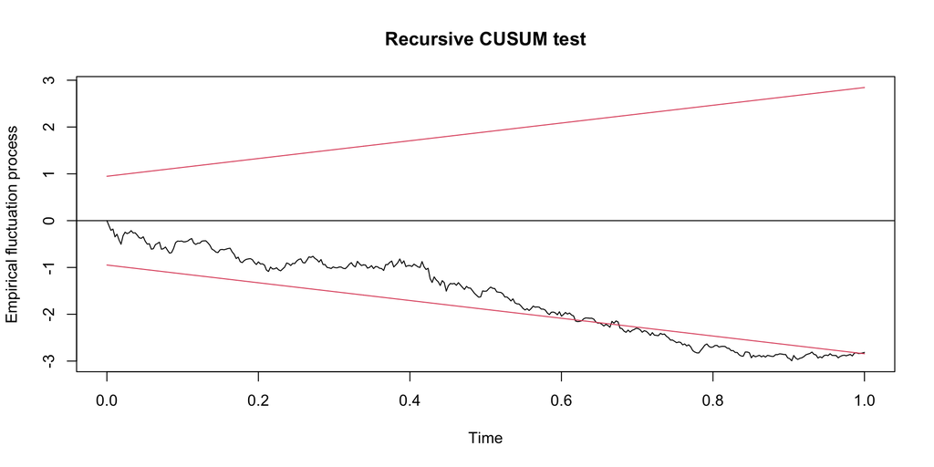

```r
plot(efp(lm_msoft, data = macro))
```

## Aplicações dos Testes

**Artigos e Dissertação**

- [Banking Financial System Stability Analysis](https://jurnal.syntax-idea.co.id/index.php/syntax-idea/article/view/1566)
- [Teste de estabilidades dos coeficientes betas do mercado acionário brasileiro](https://editorarevistas.mackenzie.br/index.php/pcg/article/view/12511)
- [Estudo empírico do comportamento dos depósitos das instituições financeiras brasileiras durante a crise de 2008](https://repositorio.fgv.br/items/dc590c57-679b-49f3-86eb-9b9020706504/full?utm_source=chatgpt.com)